# Project 4

Cortland Watson

## Brother Saunders

By hitting the Code button to the bottom right, you will be able to find my process of finding meaningful data.

```r
#hist(Credits$CumulativeEarnedCredits)

#First I looked at pairs plot to see the different variables.

#Brother Saunders then mentioned the na.omit() command. I hope to fill in the NAs with what I can so that way I will be able to have the most complete data available.

#plot(Credits$SATComposite ~ Credits$ACTComposite)
#plot(Credits$SATComposite ~ Credits$ACTConversion)
#SAT.lm <- lm(Credits$SATComposite ~ Credits$ACTConversion)
#summary(SAT.lm)

#by doing this we are able to fill in the empty spots for SAT scores.
#b <- (SAT.lm$coefficients)
#this gave me a number that was not accurate when compared to scores that already existed.
#We then consider that ACTConversion is already accounting for SAT and ACT composite scores.
#filling in the blanks for these variables would be pointless.

#I created a new dataset to simplify the data that we have to be able to sount out other variables.
#I dropped the 1,3,5,6,10,11 variables to help simplify the data.
Credits1 <- Credits[c(-1,-3,-5,-6,-10,-11)]
#View(Credits1)
#I also added a new variable to see if the students have gone over 140 credits.
Credits1$Excess <- Credits1$CumulativeEarnedCredits>140


#Now I am trying to seperate them by groups based on the number of times they have changed their degree.
#Majors <- subset(Credits1, Credits$Number.of.Majors==3)
#Majors2 <- subset(Credits1, Credits$Number.of.Majors==2)
#Majors <- subset(Credits1, Credits$Number.of.Majors==1)
#Majors3 <- subset(Credits1, Credits$Number.of.Majors==3)

#Now we run the logistic regression for each of these groups assessing the value in my model.
#Major.lm <- lm(Majors$CumulativeEarnedCredits ~ Majors$ACTConversion)
#Major2.lm <- lm(Majors2$CumulativeEarnedCredits ~ Majors2$ACTConversion)
#Major3.lm <- lm(Majors3$CumulativeEarnedCredits ~ Majors3$ACTConversion)
#Looking at these models and the simple logistic regression, we see that not much of the data is explained. We will now enter the realm of polynomial and multiple logistic regression.
```

```r
# I started by running a logistic regression based on purely the ACT conversion score. Then I went in and started to add other variables to see if I could better predict and represent the given data.
#I realized with the help of Brother Saunders that I was complicating my model by seperating the data into subgroups. He helped me to create a new model that incorporates the same thing.
Credits1.glm <- glm(Excess ~ ACTConversion + TransferStudent + I(ACTConversion^2) + as.factor(Number.of.Majors), data=Credits1, family=binomial)
#pander(summary(Credits1.glm))
#To see if running this regression is actually an appropriate thing, I run a goodness of fit test.

#pchisq(547, 422, lower.tail=FALSE)
#3.726838e-05

#With a null hypothesis being that the test is appropriate, I find that my model is not appropriate to run for this data.
```

```r
## Validating My Model
# When adding in the new data Credits2
Credits2 <- read.csv("C:/Users/Cortland/Downloads/Credits2.csv")
#View(Credits2)
Credits2$Excess <- Credits2$CumulativeEarnedCredits>140
Credits3 <- Credits2[c(-1,-3,-5,-6,-10,-11)]

#assessing the value of my model against other data sets
#newprobs <- predict(Credits1.glm, Credits3)

#what does this say, what is the risk
#pander(table(PredOver = newprobs > .4, ActualOver = Credits2$CumulativeEarnedCredits >140))
#pcc <- (238+171)/(238+171+7+14)
#pcc = .95
#Now in order to see how my model compares and explains the data given in the second dataset I run the following command to see what percentage of data my model captures.

#pcc <- (238+171)/(238+171+7+14)
#pcc = .95
```

## Real World Interpretation

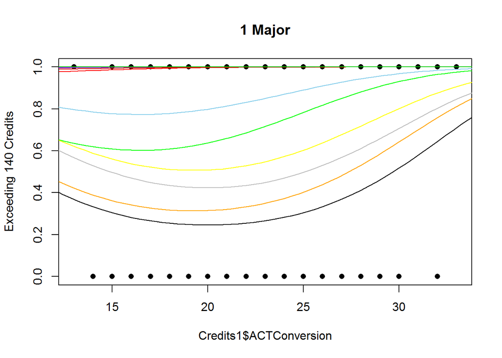

```r
b <- Credits1.glm$coefficients
plot(Credits1$Excess ~ Credits1$ACTConversion, main="1 Major", ylab='Exceeding 140 Credits', pch=16)
curve(exp(b[1]+b[2]*x+b[4]*x^2)/(1+exp(b[1]+b[2]*x+b[4]*x^2)), from=0, to=40, add=TRUE)
curve(exp(b[1]+b[2]*x+b[3]+b[4]*x^2)/(1+exp(b[1]+b[2]*x+b[3]+b[4]*x^2)), from=0, to=40, add=TRUE, col="Grey")
curve(exp(b[1]+b[2]*x+b[5]*x+b[4]*x^2)/(1+exp(b[1]+b[2]*x+b[5]*x+b[4]*x^2)), from=0, to=40, add=TRUE, col="Green")
curve(exp(b[1]+b[2]*x+b[5]*x+b[3]+b[4]*x^2)/(1+exp(b[1]+b[2]*x+b[5]*x+b[3]+b[4]*x^2)), from=0, to=40, add=TRUE, col="SkyBlue")
curve(exp(b[1]+b[2]*x+b[6]*x+b[4]*x^2)/(1+exp(b[1]+b[2]*x+b[6]*x+b[4]*x^2)), from=0, to=40, add=TRUE, col="Orange")
curve(exp(b[1]+b[2]*x+b[6]*x+b[3]+b[4]*x^2)/(1+exp(b[1]+b[2]*x+b[6]*x+b[3]+b[4]*x^2)), from=0, to=40, add=TRUE, col="Yellow")
curve(exp(b[1]+b[2]*x+b[7]*x+b[4]*x^2)/(1+exp(b[1]+b[2]*x+b[7]*x+b[4]*x^2)), from=0, to=40, add=TRUE, col="Purple")
curve(exp(b[1]+b[2]*x+b[7]*x+b[3]+b[4]*x^2)/(1+exp(b[1]+b[2]*x+b[7]*x+b[3]+b[4]*x^2)), from=0, to=40, add=TRUE, col="Purple2")
curve(exp(b[1]+b[2]*x+b[7]*x+b[3]+b[4]*x^2)/(1+exp(b[1]+b[2]*x+b[7]*x+b[3]+b[4]*x^2)), from=0, to=40, add=TRUE, col="Purple3")
curve(exp(b[1]+b[2]*x+b[8]*x+b[4]*x^2)/(1+exp(b[1]+b[2]*x+b[8]*x+b[4]*x^2)), from=0, to=40, add=TRUE, col="Red")
curve(exp(b[1]+b[2]*x+b[8]*x+b[3]+b[4]*x^2)/(1+exp(b[1]+b[2]*x+b[8]*x+b[3]+b[4]*x^2)), from=0, to=40, add=TRUE, col="Red3")
curve(exp(b[1]+b[2]*x+b[9]*x+b[4]*x^2)/(1+exp(b[1]+b[2]*x+b[9]*x+b[4]*x^2)), from=0, to=40, add=TRUE, col="Blue")
curve(exp(b[1]+b[2]*x+b[9]*x+b[3]+b[4]*x^2)/(1+exp(b[1]+b[2]*x+b[9]*x+b[3]+b[4]*x^2)), from=0, to=40, add=TRUE, col="Blue4")
curve(exp(b[1]+b[2]*x+b[10]*x+b[4]*x^2)/(1+exp(b[1]+b[2]*x+b[10]*x+b[4]*x^2)), from=0, to=40, add=TRUE, col="Green4")
curve(exp(b[1]+b[2]*x+b[10]*x+b[3]+b[4]*x^2)/(1+exp(b[1]+b[2]*x+b[10]*x+b[3]+b[4]*x^2)), from=0, to=40, add=TRUE, col="Green3")
```

### Meaning

Given the above graphic we are able to see that by using the ACT conversion score, we are able to have some predictability as to whether or not a student will exceed 140 credits. By running this for almost all observations, as some did not have an ACT Conversion score, we were able to separate the graduates into different groups by the number of times they have changed their major and if they are a transfer student.

$$Y_i = \beta_0 + \beta_1 X_{i1} + \beta_2 X_{i2} + \beta_3 X_{i3} + \beta_4 X_{i4} + \beta_5 X_{i5} + \beta_6 X_{i6} + \beta_7 X_{i7} + \beta_8 X_{i8} + \beta_9 X_{i9} + \epsilon_i$$
where we still assume $\epsilon_i \sim N(0,\sigma^2)$, but the coefficients and $X_i$ are as follows:

| Coefficient | X-Variable | Meaning |
| --- | --- | --- |
| $\beta_0$ |  | The average odds of a student exceeding 140 with an ACT conversion score of 0 |
| $\beta_1$ | $X_{i1} =$ ACT Conversion | Effect of each conversion point on average odds |
| $\beta_2$ | $X_{i2} = \left\{\begin{array}{ll} 1, & \text{if Model} = \text{Transfer} \\ 0, & \text{if Model}\neq \text{Transfer} \end{array}\right.$ | How much more or less transfer student differs opposed to non-transfer students |
| $\beta_3$ | $X_{i3} =$ ACT Conversion^2 | For every unit increase in ACT Conversion squared |
| $\beta_4$ | $X_{i4} = \left\{\begin{array}{ll} 1, & \text{if Model} = \text{2 Majors} \\ 0, & \text{if Model}\neq \text{2 Majors} \end{array}\right.$ | How much more or less a major change influences the change in odds |
| $\beta_5$ | $X_{i5} = \left\{\begin{array}{ll} 1, & \text{if Model} = \text{3 Majors} \\ 0, & \text{if Model}\neq \text{3 Majors} \end{array}\right.$ | How much more or less two major changes influences the change in odds |
| $\beta_6$ | $X_{i6} = \left\{\begin{array}{ll} 1, & \text{if Model} = \text{4 Majors} \\ 0, & \text{if Model}\neq \text{4 Majors} \end{array}\right.$ | How much more or less three major changes influence the change in odds |
| $\beta_7$ | $X_{i7} = \left\{\begin{array}{ll} 1, & \text{if Model} = \text{5 Majors} \\ 0, & \text{if Model}\neq \text{5 Majors} \end{array}\right.$ | How much more or less four major changes influence the change in odds |
| $\beta_8$ | $X_{i8} = \left\{\begin{array}{ll} 1, & \text{if Model} = \text{6 Majors} \\ 0, & \text{if Model}\neq \text{6 Majors} \end{array}\right.$ | How much more or less five major changes influence the change in odds |
| $\beta_9$ | $X_{i9} = \left\{\begin{array}{ll} 1, & \text{if Model} = \text{7 Majors} \\ 0, & \text{if Model}\neq \text{7 Majors} \end{array}\right.$ | How much more or less six major changes influence the change in odds |

### Application

Our goal is to be able to predict the odds of a student being at risk of exceeding 140 credits at BYU-Idaho.

When looking to see if a student is at risk, we must know a few factors. We need the ACT conversion score of the student being assessed, how many majors they have declared and whether or not they are a transfer student. With these three things, we will just follow the next eight steps in order to see what kind of risk they are.

1. Find the student’s ACT conversion score.
   $$Ex. 24$$
2. Multiply that conversion by -0.476476.
   $$Ex. 24*-0.476476= -11.435424$$
3. Then determine if the student is a transfer student. If yes, add 0.812200 to your answer from #2, if no add 0.
   $$Ex. -11.435424+0.812200=-10.623224$$
4. Now square the ACT conversion and then multiply that by 0.011917. Then add that number to your answer from #3.
   $$Ex. 24^2*0.011917=6.864192 -10.623224=-3.759032$$
5. Now look at the student’s number of declared majors and add the corresponding number to the answer from #4.
   $$Ex. 7 majors = 1.063-3.759032=-2.696032$$

| # of Majors | Corresponding Number |
| --- | --- |
| 1 | 0 |
| 2 | 0.08439 |
| 3 | 0.1717 |
| 4 | 0.4779 |
| 5 | 0.3426 |
| 6 | 15.63 |
| 7 | 1.063 |

6. Now add 3.640289 to your answer to step 5.
   $$Ex. -2.696032+3.640289=0.944257$$
7. We are almost done. Now just do 2.718^(Your answer for step six)/1+2.718^(Your answer for step six).
   $$Ex. (2.718^(0.944257))/(1+2.718^(0.944257))=0.719939$$
8. Just multiply your answer from step seven by 100.
   $$Ex. 100*0.719939=71.9939$$

You now have your students score when we are looking at how high of a risk they are at of exceeding 140 credits. To simplify this, I made a table where you can simply look at your final number and see where your designated student falls.

| Student Score | Risk Level of Exceeding 140 Credits |
| --- | --- |
| 0-25 | Low risk |
| 25.01-50 | Medium-Low risk |
| 50.01-75 | Medium-High risk |
| 75.01-100 | High risk |

### Limitations of my model

When I started to create the data set into a representation of the original data, I removed many factors that could have contributed greatly to my model.

I also acknowledge that my model did not pass the goodness of fit test, which means that my model is not appropriate for this data.

The variables that I selected to run my test are also variables that have been manipulated in a way that I do not know. The ACT conversion score appeared to be a combination of both the SAT and ACT composite score.

On that note, I ran the validation of my model to see how well it could account for the other data set, and I found a shocking result. It appears that my model accounts for .95 of the second data set. This means that my model does have something to contribute while looking at other observations of this same kind.